# STAT S 670 - Exploratory Data Analysis - Midterm

Ganesh Nagarajan, gnagaraj@indiana.edu

November 3, 2015

1. 1. Calculate 5 Number summary fow wt2

```r
wt2<-c(143,-184,182,-110,1017,986,1010,1001,-111,-60,-151,-111,1024,1031,1028)
summary(wt2)
```

```
##    Min. 1st Qu.  Median    Mean 3rd Qu.    Max.
##  -184.0  -110.5   182.0   446.3  1014.0  1031.0
```

2. Stem leaf plot

According to Tukey, the range of the dataset determines the lines on the stem leaf plot. Range can be given as follows,

```r
library(aplpack)
range.wt2<-(range(wt2)[2]-range(wt2)[1])/length(wt2)
range.wt2
```

```
## [1] 81
```

```r
stem.leaf(wt2,100)
```

```
## 1 | 2: represents 1200
##  leaf unit: 100
##             n: 15
##    6    -0* | 111110
##   (2)    0* | 11
##           t |
##           f |
##           s |
##    7     0. | 9
##    6     1* | 000000
```

Another way of representing this is using the stem command,

```r
stem(wt2,2)
```

```
##
##   The decimal point is 2 digit(s) to the right of the |
##
##   -0 | 851116
##    0 | 48
##    2 |
##    4 |
##    6 |
##    8 | 9
##   10 | 012233
```

Below is the box plot of wt2 and it can be seen that there are no outliers.

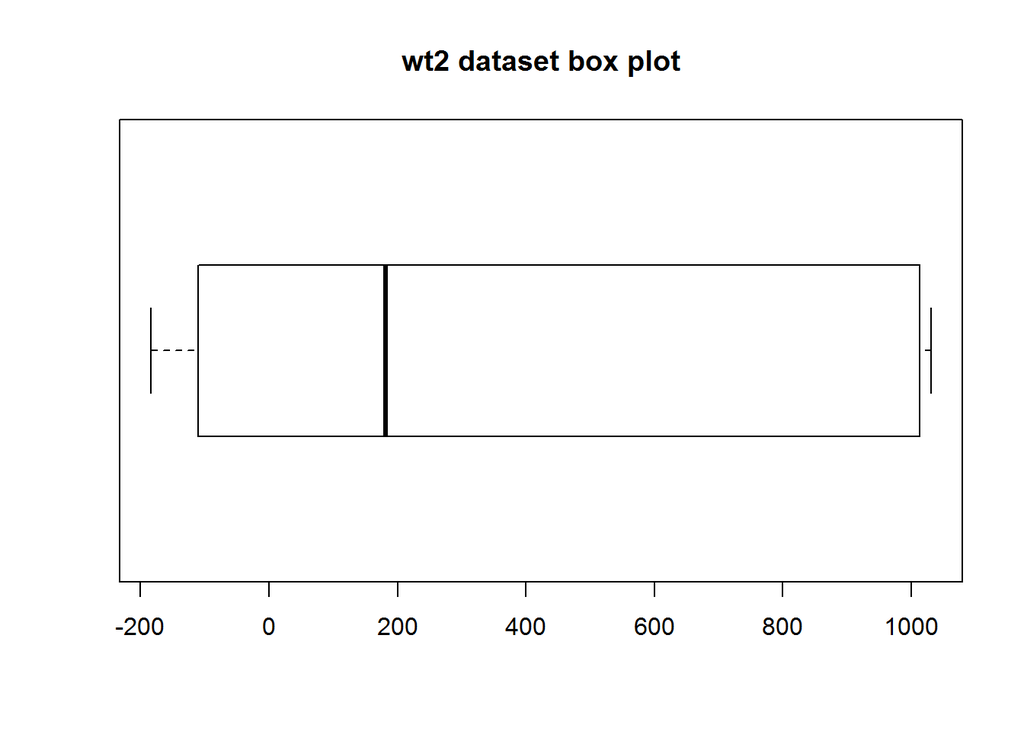

```r
boxplot(wt2,horizontal = TRUE,main="wt2 dataset box plot")
```

2. “Outsides values in a box plot”

```r
noOutliers<-function(x){0.4+(0.007*x)}
noOutliers(5000)
```

```
## [1] 35.4
```

Lets check the correctness of above predicted number. Lets generate 5000 random values and check the outliers.

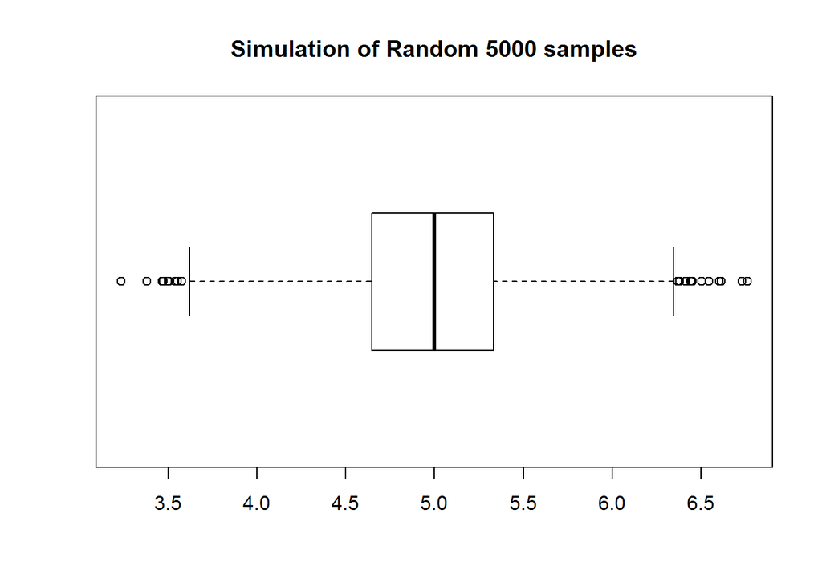

```r
set.seed(3)
boxplot(rnorm(5000,mean=5,sd=0.5),horizontal = TRUE,main="Simulation of Random 5000 samples")
```

Above graph has about 30 outliers which is right about the estimate we have done.

Examples of Linear Smoothers,

1. Running Mean
2. Cubic Spline Smoothers
3. Lowess Smoother

Disadvantages of Linear Smoother,

1. Over fits the data, attempts to fit every point available
2. Since it attempts to fit every point, they are affected by outliers
3. Some linear smoothers like LOWESS filters require fairly dense points for smoothing.

Advantage and Disadvantage of Non linear smoothers

1. Since Non linear smoothers doesn’t have linear constraints, they are quite flexible
2. Since they involve medians, they are more robust than the other methods and are less affected by the outliers
3. Requires more computation than linear smoothers. Usually require denser data.
4. 1. Initial RR line on the plot.

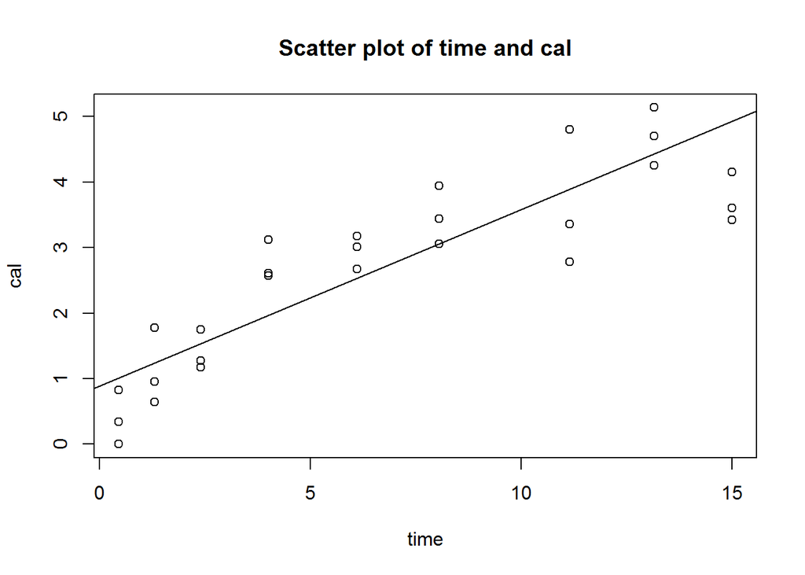

```r
source("myplotfit.r")
source("rrline.r")
x<-c(0.450,0.45,0.450,1.300,1.300,1.300,2.400,2.400,2.400,4.000,4.00,4.000,6.100,6.100,6.100,8.05,8.050,8.050,11.150,11.150,11.150,13.150,13.150,13.150,15.000,15.00,15.000)
y<-c(0.342,0.00,0.825,1.780,0.954,0.641,1.751,1.275,1.173,3.123,2.61,2.574,3.179,3.008,2.671,3.06,3.943,3.437,4.807,3.356,2.783,5.138,4.703,4.257,3.604,4.15,3.425)
#Run one iteration of RR
rrline.x<-rrline1(x,y)
plot(x,y,main="Scatter plot of time and cal",xlab = "time",ylab = "cal")
abline(rrline.x$a,rrline.x$b)
```

```r
paste("Intercept : ",rrline.x$a," Slope : ",rrline.x$b)
```

```
## [1] "Intercept :  0.888877637130801  Slope :  0.269704641350211"
```

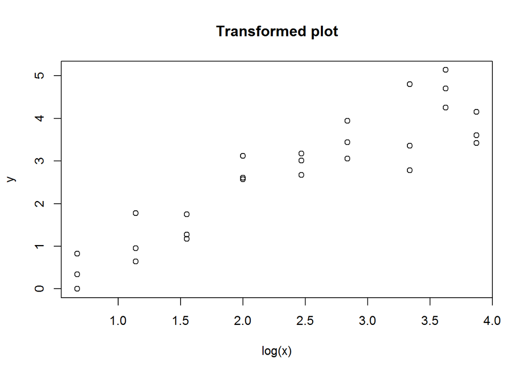

```r
sqrtx<-sqrt(x)
plot(sqrtx,y,main="Transformed plot",xlab="log(x)",ylab="y")
```

4. RR on panel b

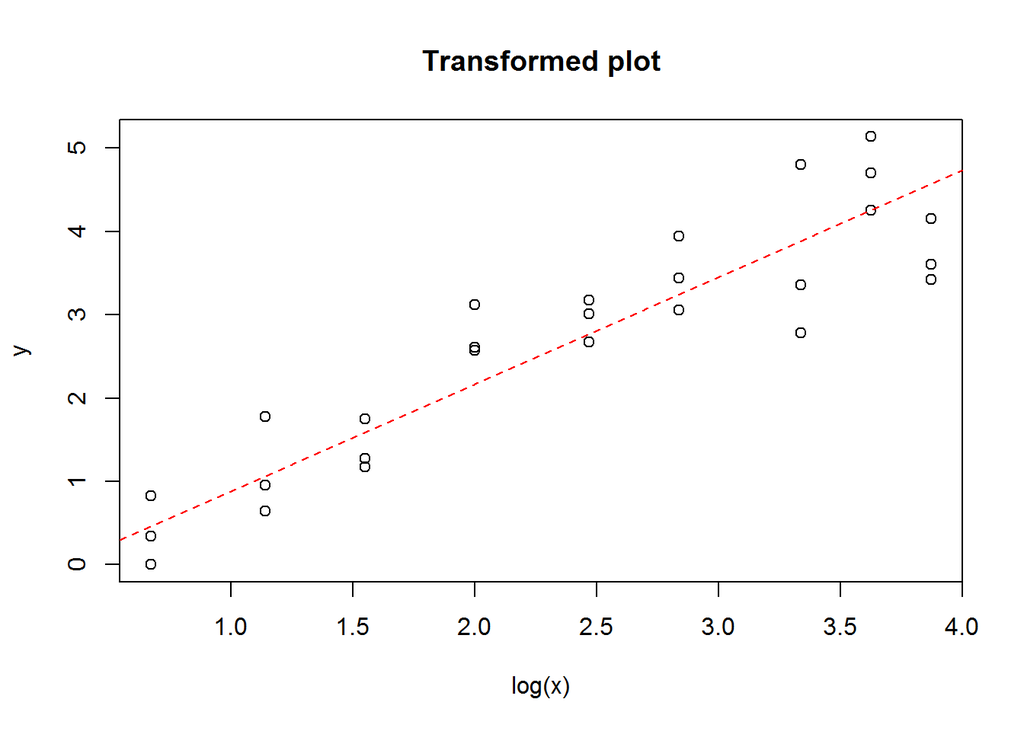

```r
sqrtx<-sqrt(x)
plot(sqrtx,y,main="Transformed plot",xlab="log(x)",ylab="y")
rrline.sqrtx<-rrline1(sqrtx,y)
abline(rrline.sqrtx$a,rrline.sqrtx$b,lty=2,col="red")
```

```r
paste("Intercept : ",rrline.sqrtx$a," Slope : ",rrline.sqrtx$b)
```

```
## [1] "Intercept :  -0.404739545752101  Slope :  1.28553862281732"
```

```r
rrline.x$sumres
```

```
## [1] 16.38401
```

```r
rrline.sqrtx$sumres
```

```
## [1] 13.13373
```

Also an observation is that sum of residuals of plot b is lesser than plot a, ie the model fits better than the plot 1.

6. RR after two iterations.

```r
source("myplotfit.r")
source("rrline.r")
x<-c(0.450,0.45,0.450,1.300,1.300,1.300,2.400,2.400,2.400,4.000,4.00,
     4.000,6.100,6.100,6.100,8.05,8.050,8.050,11.150,11.150,11.150,
     13.150,13.150,13.150,15.000,15.00,15.000)
y<-c(0.342,0.00,0.825,1.780,0.954,0.641,1.751,1.275,1.173,3.123,2.61,
     2.574,3.179,3.008,2.671,3.06,3.943,3.437,4.807,3.356,2.783,5.138,
     4.703,4.257,3.604,4.15,3.425)

intercept <- 0.256
slope <- -0.124
residuals <- y-slope*x-intercept
#Iteration 1
rr1<-rrline1(x,residuals)
paste("Intercept : ",rr1$a," Slope : ",rr1$b)
```

```
## [1] "Intercept :  0.560189873417722  Slope :  0.40273417721519"
```

```r
#Iteration 2
residuals <- y - rr1$b - rr1$b
rr1<-rrline1(x,residuals)
paste("Intercept : ",rr1$a," Slope : ",rr1$b)
```

```
## [1] "Intercept :  0.0834092827004214  Slope :  0.269704641350211"
```

6. 1. Median Polish

```r
source("myplotfit.r")
source("rrline.r")
red<-c(5,6,3,11,10)
white<-c(14,10,6,12,21)
pink<-c(16,24,15,26,32)
mat<-rbind(red,white,pink)
colnames(mat)<-c("A1","A2","A3","A4","A5")
res<-medpolish(mat)
```

```
## 1: 28
## Final: 28
```

```r
print(res)
```

```
##
## Median Polish Results (Dataset: "mat")
##
## Overall: 12
##
## Row Effects:
##   red white  pink
##    -6     0    12
##
## Column Effects:
## A1 A2 A3 A4 A5
## -1  0 -6  2  8
##
## Residuals:
##       A1 A2 A3 A4 A5
## red    0  0  3  3 -4
## white  3 -2  0 -2  1
## pink  -7  0 -3  0  0
```

The row effects suggest that Pink area has the maximum visit (12) and column effects suggests that Area 5 (8) have highest visitors.

2. Quality of the fit can be given by Analog R2. Its curious that the overall effects (12) is same as the median (12).

```r
Analog_R_Square<- 1-((sum(abs(res$residuals))) /(sum(abs(mat-res$overall))))
paste("Analog R2 : ",Analog_R_Square)
```

```
## [1] "Analog R2 :  0.711340206185567"
```

3. Diagnostic Plot

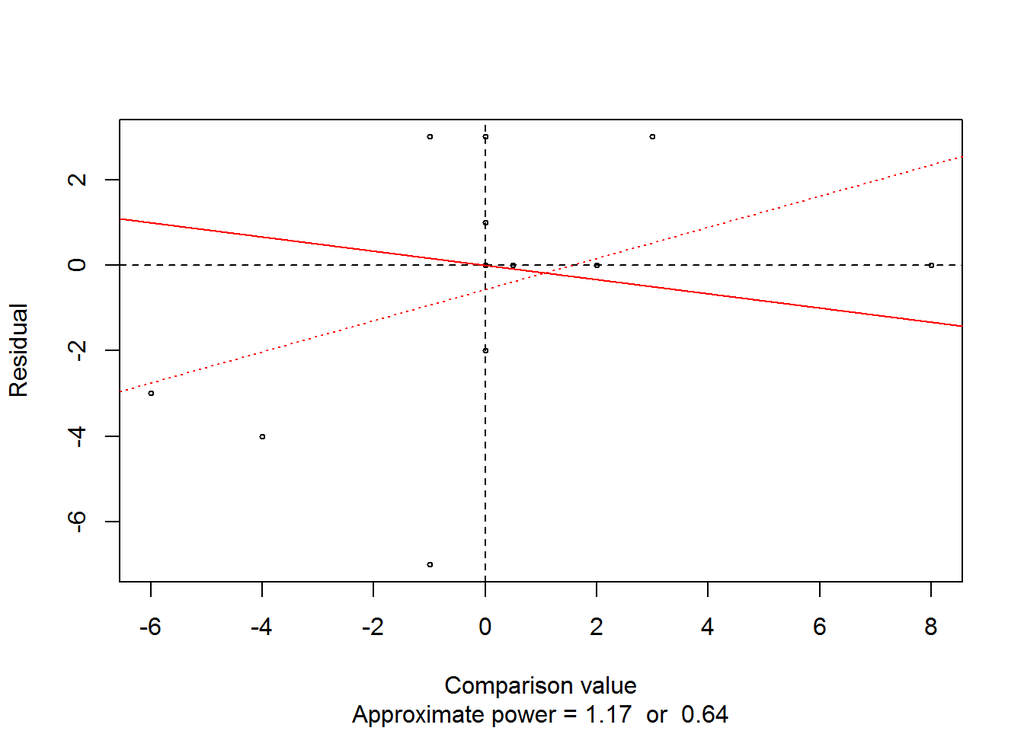

```
##    a        b    |res|
##  1 0  1.00000 31.50000
##  2 0 -1.16667 31.91667
##  3 0  1.66667 43.25000
##  4 0 -1.50000 28.00000
##  5 0  1.00000 31.50000
##  6 0 -1.16667 31.91667
##  7 0  1.66667 43.25000
##  8 0 -1.50000 28.00000
##  9 0  1.00000 31.50000
## 10 0 -1.16667 31.91667
##    0 -0.16667 31.91667
```

```r
diag.MP(res)
```

Diagnostic plot tells us that how good the model is. If the residuals are along 0, Then the model is good.